# Diagnostics and Remedial Measures in $R$

### Box-Cox transfomations for Plasma Levels Example

The Box-Cox method searches over a range of possible transformations and finds the optimal one. `boxcox()` produces a plot of the profile log-likelihood values (the definition of this term is beyond the scope of this class) as a function of $\lambda$

The plot should have an upside-down U shape, and the optimal $\lambda$ value is the one at which the log-likelihood is maximized. The object you assign the output to (below, LAMBDA) will contain elements x and y (note: these are NOT our explanatory and response variables) corresponding to the points being plotted to create the figure. These can be used to extract the optimal $\lambda$ value using `which()`.

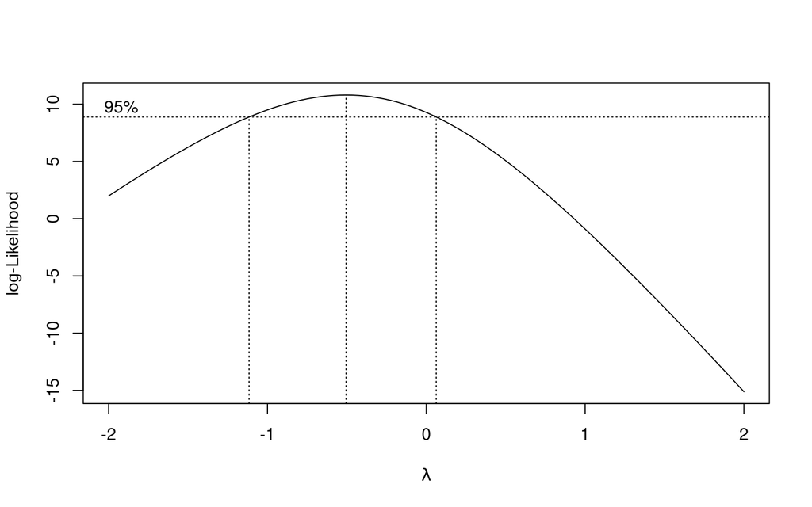

```r
# ALSM no longer works!
#library(ALSM)
#obj <- boxcox.sse(plasmaData$age, plasmaData$plasmaLevel, l=seq(-2,2,.1))
#obj
#obj[which.min(obj$SSE),]


library(MASS)
fit <- lm(plasmaLevel ~ age,data = plasmaData)
LAMBDA <- boxcox(fit, lambda = seq(-2, 2, 0.1))
```

```r
LAMBDA$x[which(LAMBDA$y == max(LAMBDA$y))]
```

```
[1] -0.5050505
```

The optimal value for this example is -0.5050505, which we can round to -0.5. Thus, our Box-Cox transformation is $1/\sqrt{Y}$.

### lowess Method for Toluca example

```r
toluca <- read.table("http://www.cnachtsheim-text.csom.umn.edu/Kutner/Chapter%20%201%20Data%20Sets/CH01TA01.txt", sep ="" , header = FALSE)


colnames(toluca) <- c("lotSize", "hours")

tolucaDF <- data.frame(toluca)
head(tolucaDF)
```

```
  lotSize hours
1      80   399
2      30   121
3      50   221
4      90   376
5      70   361
6      60   224
```

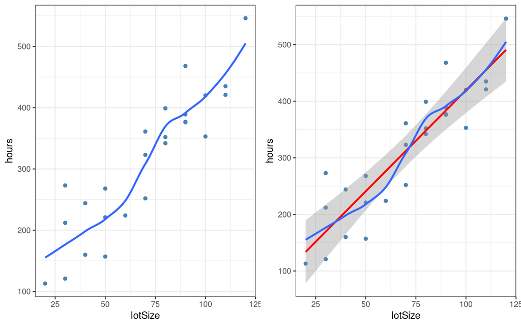

```r
library(cowplot)
p1 <- ggplot(data = tolucaDF, aes(x = lotSize, y=hours)) +
  geom_point(color = "steelblue") +
  geom_smooth(method = "loess", se = FALSE)+
  theme_bw()

p2 <- ggplot(data = tolucaDF, aes(x = lotSize, y=hours)) +
  geom_point(color = "steelblue") +
  geom_smooth(method = "lm", se = TRUE, level = 0.99, color = "red")+
    geom_smooth(method = "loess",  se = FALSE)+
  theme_bw()

plot_grid(p1, p2)
```